# In-Class Ginkgo Data Exploration

Timothy Nsubuga

11/23/2021

## Objectives

Import ginkgo data

perform basic graphical exploration

## Instructions

Retrieve the ginkgo data 2021 file and read it into a data.frame object.

```r
require(here)
gink_dat = read.csv(here('data','ginkgo_data_2021.csv'))
```

## Questions

### Q1 (1 pt.): Create a conditional boxplot of one of the continuous variables (notch) conditioned on the seeds_present column.

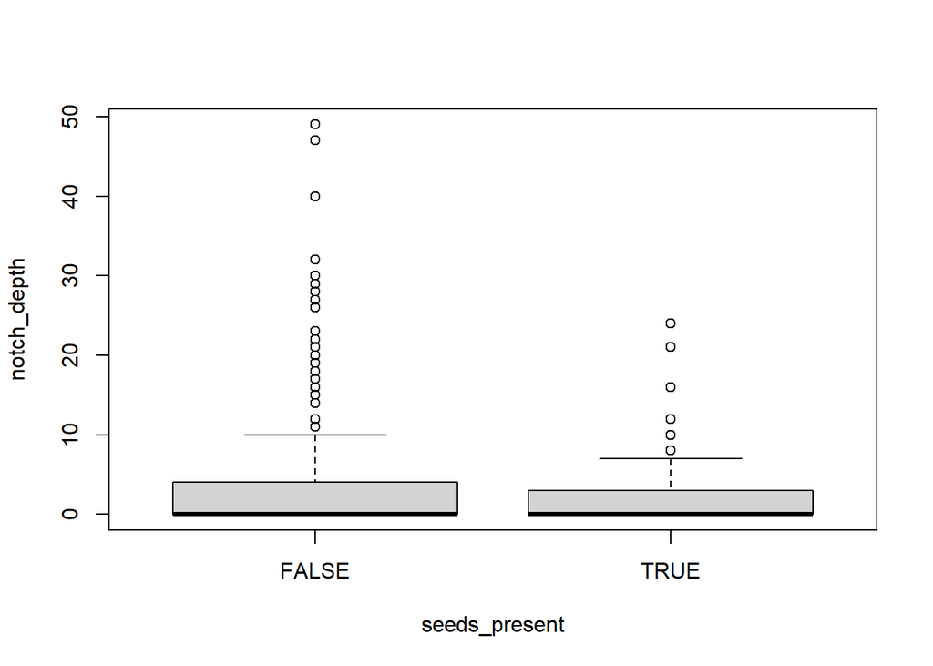

```r
boxplot(notch_depth ~ seeds_present,
        data = gink_dat)
```

### Q2 (1 pt.): Based on your boxplot, do you think there is any difference betwen seed bearing and non seed bearing trees? Note: this is just a prelimnary data exploration, you may change your mind based on further analysis!

No.

### Q3 (1 pt.): Create a scatterplot of max leaf depth (x) and max leaf width (y).

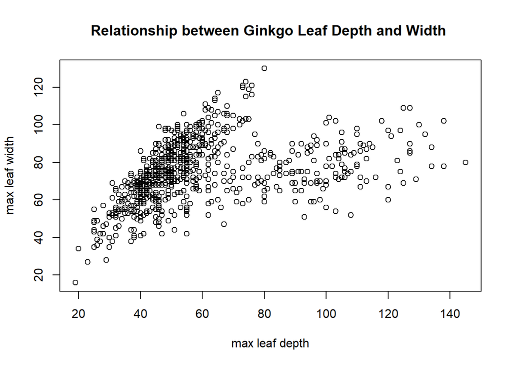

```r
plot(x = gink_dat$max_depth,
     y = gink_dat$max_width,
     main = "Relationship between Ginkgo Leaf Depth and Width ",
     xlab = "max leaf depth",
     ylab = "max leaf width")
```

### Q4 (1 pt.): Qualitatively describe the patterns you see in the scatterplot.

The majority of leaf samples collected had a max leaf deoth between 40-60 max leaf depth.

### Q5 (1 pt.): Explain how our data collection procedure might have violated the fixed x assumption.

We could have accidentally collected leaves from a tree that was not the assigned ID, but rather a neighboring tree.

### Q6 (1 pt.): Name 1 or more concepts you’d like me to review or discuss in more detail during our last two class meetings.

It would be interesting to have an introduction to Bayesian statistics and to know if it is possible to use this framework in all the model types we have reviewed.